# Project: Prosper Loan Data Exploration

### Submitted by: Ahmed Mohamed Hussein Unshur

### Table of Contents:

- 1. Introduction
- 2. Preliminary Wrangling
- 3. Univariate Explorations
- 4. Bivariate Explorations
- 5. Multivariate Explorations
- 6. Conclusion
- 7. Sources

# 1. Introduction

The following project is a data visualization project that was completed as part of [Udacity’s Data Analyst Nanodegree](https://www.udacity.com/course/data-analyst-nanodegree--nd002) program.

The project explores and visualizes loan data from [Prosper](https://www.prosper.com/) which is a peer-to-peer lending company based in San Francisco, CA, USA. The dataset contains 113,937 loans with 81 variables on each loan, including loan amount, borrower's Annual Percentage Rate (APR), borrower's income range, loan term, and many others. The dataset can be downloaded from this [link](https://s3.amazonaws.com/udacity-hosted-downloads/ud651/prosperLoanData.csv). Also, see this [dictionary](https://www.google.com/url?q=https://docs.google.com/spreadsheet/ccc?key%3D0AllIqIyvWZdadDd5NTlqZ1pBMHlsUjdrOTZHaVBuSlE%26usp%3Dsharing&sa=D&ust=1554486256024000) to understand its variables.

In this project, we will first wrangle the date and then conduct exploratory analysis producing univariate, bivariate, and multivariate visualizations. Finaly, we will generate explanatory data visualizations.

# 2. Preliminary Wrangling

In this section, we will conduct a preliminary wrangling on the dataset and describe its properties.

But first, we will import required packages and load the dataset into a Pandas dataframe. Finally, we will motivate our exploration goals.

```python
# Import required packages.
import numpy as np
import pandas as pd
import matplotlib.pyplot as plt
import seaborn as sb

# Enable inline plotting.
%matplotlib inline

# Ignore warnings.
import warnings
warnings.simplefilter("ignore")
```

```python
# Load dataset.
loan_data = pd.read_csv('prosperLoanData.csv')

# Show all columns of the dataset.
pd.set_option('display.max_columns', None)
```

```python
# Print number of columns and rows within the dataset.
print(loan_data.shape)

# View the first 10 rows of the dataset.
loan_data.head(10)
```

```
(113937, 81)
```

|  | ListingKey | ListingNumber | ListingCreationDate | CreditGrade | Term | LoanStatus | ClosedDate | BorrowerAPR | BorrowerRate | LenderYield | EstimatedEffectiveYield | EstimatedLoss | EstimatedReturn | ProsperRating (numeric) | ProsperRating (Alpha) | ProsperScore | ListingCategory (numeric) | BorrowerState | Occupation | EmploymentStatus | EmploymentStatusDuration | IsBorrowerHomeowner | CurrentlyInGroup | GroupKey | DateCreditPulled | CreditScoreRangeLower | CreditScoreRangeUpper | FirstRecordedCreditLine | CurrentCreditLines | … |
| --- | --- | --- | --- | --- | --- | --- | --- | --- | --- | --- | --- | --- | --- | --- | --- | --- | --- | --- | --- | --- | --- | --- | --- | --- | --- | --- | --- | --- | --- | --- |
| 0 | 1021339766868145413AB3B | 193129 | 2007-08-26 19:09:29.263000000 | C | 36 | Completed | 2009-08-14 00:00:00 | 0.16516 | 0.1580 | 0.1380 | NaN | NaN | NaN | NaN | NaN | NaN | 0 | CO | Other | Self-employed | 2.0 | True | True | NaN | 2007-08-26 18:41:46.780000000 | 640.0 | 659.0 | 2001-10-11 00:00:00 | 5.0 | … |
| 1 | 10273602499503308B223C1 | 1209647 | 2014-02-27 08:28:07.900000000 | NaN | 36 | Current | NaN | 0.12016 | 0.0920 | 0.0820 | 0.07960 | 0.0249 | 0.05470 | 6.0 | A | 7.0 | 2 | CO | Professional | Employed | 44.0 | False | False | NaN | 2014-02-27 08:28:14 | 680.0 | 699.0 | 1996-03-18 00:00:00 | 14.0 | … |
| 2 | 0EE9337825851032864889A | 81716 | 2007-01-05 15:00:47.090000000 | HR | 36 | Completed | 2009-12-17 00:00:00 | 0.28269 | 0.2750 | 0.2400 | NaN | NaN | NaN | NaN | NaN | NaN | 0 | GA | Other | Not available | NaN | False | True | 783C3371218786870A73D20 | 2007-01-02 14:09:10.060000000 | 480.0 | 499.0 | 2002-07-27 00:00:00 | NaN | … |
| 3 | 0EF5356002482715299901A | 658116 | 2012-10-22 11:02:35.010000000 | NaN | 36 | Current | NaN | 0.12528 | 0.0974 | 0.0874 | 0.08490 | 0.0249 | 0.06000 | 6.0 | A | 9.0 | 16 | GA | Skilled Labor | Employed | 113.0 | True | False | NaN | 2012-10-22 11:02:32 | 800.0 | 819.0 | 1983-02-28 00:00:00 | 5.0 | … |
| 4 | 0F023589499656230C5E3E2 | 909464 | 2013-09-14 18:38:39.097000000 | NaN | 36 | Current | NaN | 0.24614 | 0.2085 | 0.1985 | 0.18316 | 0.0925 | 0.09066 | 3.0 | D | 4.0 | 2 | MN | Executive | Employed | 44.0 | True | False | NaN | 2013-09-14 18:38:44 | 680.0 | 699.0 | 2004-02-20 00:00:00 | 19.0 | … |
| 5 | 0F05359734824199381F61D | 1074836 | 2013-12-14 08:26:37.093000000 | NaN | 60 | Current | NaN | 0.15425 | 0.1314 | 0.1214 | 0.11567 | 0.0449 | 0.07077 | 5.0 | B | 10.0 | 1 | NM | Professional | Employed | 82.0 | True | False | NaN | 2013-12-14 08:26:40 | 740.0 | 759.0 | 1973-03-01 00:00:00 | 21.0 | … |
| 6 | 0F0A3576754255009D63151 | 750899 | 2013-04-12 09:52:56.147000000 | NaN | 36 | Current | NaN | 0.31032 | 0.2712 | 0.2612 | 0.23820 | 0.1275 | 0.11070 | 2.0 | E | 2.0 | 1 | KS | Sales - Retail | Employed | 172.0 | False | False | NaN | 2013-04-12 09:52:53 | 680.0 | 699.0 | 2000-09-29 00:00:00 | 10.0 | … |
| 7 | 0F1035772717087366F9EA7 | 768193 | 2013-05-05 06:49:27.493000000 | NaN | 36 | Current | NaN | 0.23939 | 0.2019 | 0.1919 | 0.17830 | 0.0799 | 0.09840 | 4.0 | C | 4.0 | 2 | CA | Laborer | Employed | 103.0 | False | False | NaN | 2013-05-05 06:49:25 | 700.0 | 719.0 | 1999-02-25 00:00:00 | 6.0 | … |
| 8 | 0F043596202561788EA13D5 | 1023355 | 2013-12-02 10:43:39.117000000 | NaN | 36 | Current | NaN | 0.07620 | 0.0629 | 0.0529 | 0.05221 | 0.0099 | 0.04231 | 7.0 | AA | 9.0 | 7 | IL | Food Service | Employed | 269.0 | True | False | NaN | 2013-12-02 10:43:39 | 820.0 | 839.0 | 1993-04-01 00:00:00 | 17.0 | … |
| 9 | 0F043596202561788EA13D5 | 1023355 | 2013-12-02 10:43:39.117000000 | NaN | 36 | Current | NaN | 0.07620 | 0.0629 | 0.0529 | 0.05221 | 0.0099 | 0.04231 | 7.0 | AA | 11.0 | 7 | IL | Food Service | Employed | 269.0 | True | False | NaN | 2013-12-02 10:43:39 | 820.0 | 839.0 | 1993-04-01 00:00:00 | 17.0 | … |

```python
# Show concise summary of the dataframe.
loan_data.info()
```

```
<class 'pandas.core.frame.DataFrame'>
RangeIndex: 113937 entries, 0 to 113936
Data columns (total 81 columns):
 #   Column                               Non-Null Count   Dtype
---  ------                               --------------   -----
 0   ListingKey                           113937 non-null  object
 1   ListingNumber                        113937 non-null  int64
 2   ListingCreationDate                  113937 non-null  object
 3   CreditGrade                          28953 non-null   object
 4   Term                                 113937 non-null  int64
 5   LoanStatus                           113937 non-null  object
 6   ClosedDate                           55089 non-null   object
 7   BorrowerAPR                          113912 non-null  float64
 8   BorrowerRate                         113937 non-null  float64
 9   LenderYield                          113937 non-null  float64
```

[output cut: 73 more lines]

The dataset contains 113,937 rows (loans) and 81 columns (features).

We are interested in finding out what features affect the borrower's Annual Percentage Rate (APR) and the original loan amount.

We think that the following features with help support our investigation into the features of interest: loan term, Prosper rating, Prosper score, borrower's income range, and their home ownership status.

For this reason, we will only select columns of those features and then clean the data.

```python
# Select 8 features from the dataset.
loan_data = loan_data[['LoanKey', 'LoanOriginalAmount', 'BorrowerAPR',
                       'Term', 'ProsperRating (Alpha)', 'ProsperScore',
                       'IncomeRange', 'IsBorrowerHomeowner']]
```

```python
# View the first 5 rows of the dataframe.
loan_data.head()
```

|  | LoanKey | LoanOriginalAmount | BorrowerAPR | Term | ProsperRating (Alpha) | ProsperScore | IncomeRange | IsBorrowerHomeowner |
| --- | --- | --- | --- | --- | --- | --- | --- | --- |
| 0 | E33A3400205839220442E84 | 9425 | 0.16516 | 36 | NaN | NaN | $25,000-49,999 | True |
| 1 | 9E3B37071505919926B1D82 | 10000 | 0.12016 | 36 | A | 7.0 | $50,000-74,999 | False |
| 2 | 6954337960046817851BCB2 | 3001 | 0.28269 | 36 | NaN | NaN | Not displayed | False |
| 3 | A0393664465886295619C51 | 10000 | 0.12528 | 36 | A | 9.0 | $25,000-49,999 | True |
| 4 | A180369302188889200689E | 15000 | 0.24614 | 36 | D | 4.0 | $100,000+ | True |

```python
# Show concise summary of the dataframe.
loan_data.info()
```

```
<class 'pandas.core.frame.DataFrame'>
RangeIndex: 113937 entries, 0 to 113936
Data columns (total 8 columns):
 #   Column                 Non-Null Count   Dtype
---  ------                 --------------   -----
 0   LoanKey                113937 non-null  object
 1   LoanOriginalAmount     113937 non-null  int64
 2   BorrowerAPR            113912 non-null  float64
 3   Term                   113937 non-null  int64
 4   ProsperRating (Alpha)  84853 non-null   object
 5   ProsperScore           84853 non-null   float64
 6   IncomeRange            113937 non-null  object
 7   IsBorrowerHomeowner    113937 non-null  bool
dtypes: bool(1), float64(2), int64(2), object(3)
memory usage: 6.2+ MB
```

```python
# Show sum of duplicates.
loan_data.duplicated().sum()
```

```
0
```

The new dataframe contains 113937 rows and 8 columns with no duplicates. But there are some columns with missing values.

```python
# Show total missing values in column.
loan_data.isna().sum()
```

```
LoanKey                      0
LoanOriginalAmount           0
BorrowerAPR                 25
Term                         0
ProsperRating (Alpha)    29084
ProsperScore             29084
IncomeRange                  0
IsBorrowerHomeowner          0
dtype: int64
```

The output above shows that `BorrowerAPR` has 25 missing values, and `ProsperRating (Alpha)` and `ProsperScore` with missing values of 29084.

```python
# Drop rows with missing values.
loan_data.dropna(inplace = True)
```

```python
# Show total missing values in column.
loan_data.isna().sum()
```

```
LoanKey                  0
LoanOriginalAmount       0
BorrowerAPR              0
Term                     0
ProsperRating (Alpha)    0
ProsperScore             0
IncomeRange              0
IsBorrowerHomeowner      0
dtype: int64
```

```python
# Show summary of the dataframe.
loan_data.info()
```

```
<class 'pandas.core.frame.DataFrame'>
Int64Index: 84853 entries, 1 to 113936
Data columns (total 8 columns):
 #   Column                 Non-Null Count  Dtype
---  ------                 --------------  -----
 0   LoanKey                84853 non-null  object
 1   LoanOriginalAmount     84853 non-null  int64
 2   BorrowerAPR            84853 non-null  float64
 3   Term                   84853 non-null  int64
 4   ProsperRating (Alpha)  84853 non-null  object
 5   ProsperScore           84853 non-null  float64
 6   IncomeRange            84853 non-null  object
 7   IsBorrowerHomeowner    84853 non-null  bool
dtypes: bool(1), float64(2), int64(2), object(3)
memory usage: 5.3+ MB
```

Final dataset contains 84853 rows and 8 columns.

In the following sections, we will conduct univariate, bivariate, and multivariate explorations by visualizing single variables and relationships between two or more variables.

# 3. Univariate Explorations

In this section, we will explore variables one by one.

### 3.1. Borrower's Annual Percentage Rate (APR)

What is the distribution of the borrower's Annual Percentage Rate (APR)?

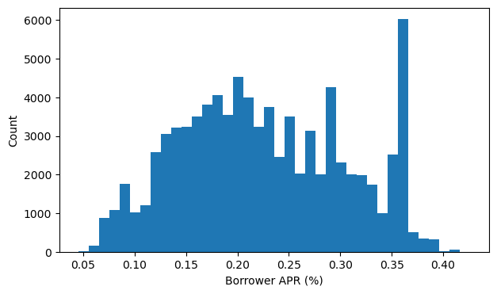

```python
# Visualize distribution of borrower's APR.
plt.figure(figsize = [7, 4])
bins = np.arange(loan_data.BorrowerAPR.min(), loan_data.BorrowerAPR.max()+0.01, 0.01)
plt.hist(data = loan_data, x = 'BorrowerAPR', bins = bins)
plt.xlabel('Borrower APR (%)')
plt.ylabel('Count')
plt.show()
```

### 3.2. Original Loan Amount

What is the distribution of the original loan amount?

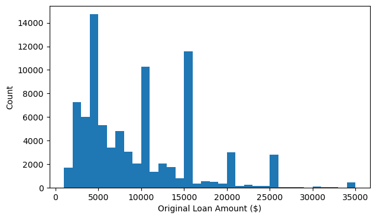

```python
# Visualize distribution of original loan amount.
plt.figure(figsize = [7, 4])
bins = np.arange(loan_data.LoanOriginalAmount.min(), loan_data.LoanOriginalAmount.max()+1000, 1000)
plt.hist(data = loan_data, x = 'LoanOriginalAmount', bins = bins)
plt.xlabel('Original Loan Amount ($)')
plt.ylabel('Count')
plt.show()
```

### 3.3. Term (Length of the Loan Expressed in Months)

What is the distribution of term (the length of the loan expressed in months)?

```python
# Function to create vertical barplot with seaborn.
def barplot_v(i):
    plt.figure(figsize = [7, 4])
    color = sb.color_palette()[0]
    sb.countplot(data = loan_data, x = i, color = color);

# Function to create horizental barplot with seaborn.
def barplot_h(i):
    plt.figure(figsize = [7, 4])
    color = sb.color_palette()[0]
    sb.countplot(data = loan_data, y = i, color = color);
```

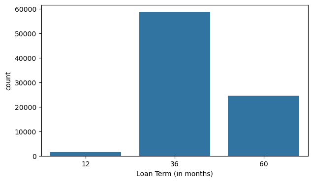

```python
# Plot the distribution of `term`.
barplot_v('Term')
plt.xlabel('Loan Term (in months)')
plt.show()
```

The bar plot above shows that the number of loans of 36 months (3 years) is more than double of that of loans of 60 months (5 years). The plot also shows that the number of loans of 12 months (1 year) is very small compared to the other two terms.

So, majority of borrowers take loans with a length of 3 years.

### 3.4. Prosper Score

What is the distribution of Prosper score?

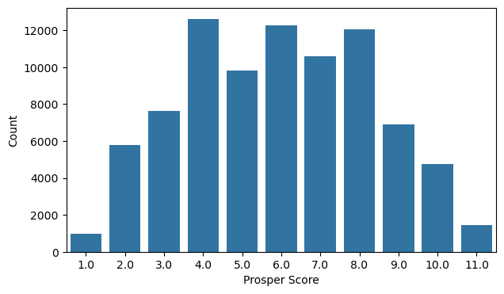

```python
# Plot the distribution of the Prosper score?
barplot_v('ProsperScore')
plt.xlabel('Prosper Score')
plt.ylabel('Count');
```

The plot above illustrates that majority of borrowers get Prosper score of between 4 and 8.

### 3.5. Prosper Ratings

What is the distribution of the Prosper rating?

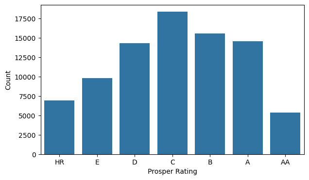

```python
# Prosper rating levels.
prosper_ratings = ['HR', 'E', 'D', 'C', 'B', 'A', 'AA']

# Return prosper ratings with categories and orderedness.
ratings = pd.api.types.CategoricalDtype(ordered = True, categories = prosper_ratings)

# Convert 'ProsperRating (Alpha)' column into an ordered categorical type.
loan_data['ProsperRating (Alpha)'] = loan_data['ProsperRating (Alpha)'].astype(ratings);

# Plot distribution of Prosper rating.
barplot_v('ProsperRating (Alpha)')
plt.xlabel('Prosper Rating')
plt.ylabel('Count');
```

The graph above shows that most borrowers get a Prosper tating of 'C'. Coming second are those with Prosper rating of 'B', while those with ratings of 'A' and 'D' are about equal. The number of borrowers with a rating of 'AA' is the smallest.

### 3.6. Home Ownership

What is the distribution of home ownership among borrowers?

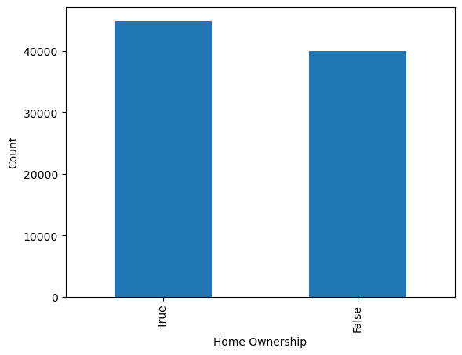

```python
# Plot distribution of home ownership.
loan_data.IsBorrowerHomeowner.value_counts().plot(kind = 'bar')
plt.xlabel('Home Ownership')
plt.ylabel('Count')
plt.show()
```

The bar plot above indicates that the number of borrowers that own a home is slightly higher than that of those who don't.

### 3.7. Borrower's Income Range

What is the distribution of the borrower's income range?

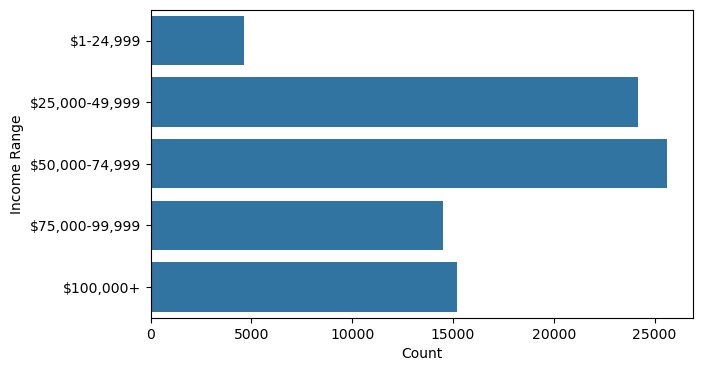

```python
# Income ranges.
income_range = ['$1-24,999', '$25,000-49,999', '$50,000-74,999', '$75,000-99,999', '$100,000+']

# Return income range with categories and orderedness
income = pd.api.types.CategoricalDtype(ordered = True, categories = income_range)

# Convert 'IncomeRange' column into an ordered categorical type.
loan_data['IncomeRange'] = loan_data['IncomeRange'].astype(income);

# Plot distribution of income ranges.
barplot_h('IncomeRange')
plt.xlabel('Count')
plt.ylabel('Income Range');
```

The horizental bar plot above shows that individuals with an income range of `$50,000-74,999` are the ones who take loans the most. Coming second are those with an income range of `$25,000-49,999`. Those with an income range of `$1-24,999` take loans the least.

# 4. Bivariate Explorations

In this section, we will explore relationships between two variables.

### 4.1. Relationship Between Borrower APR and Original Loan Amount

Is there a relationship between Borrower APR and original loan amount?

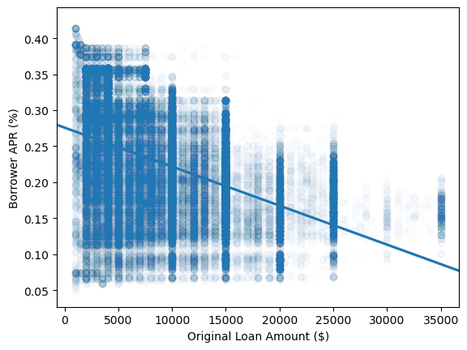

```python
# Visualize relationship between borrower APR and laon amount using Seaborn's regplot() function.
sb.regplot(data = loan_data, x = 'LoanOriginalAmount', y = 'BorrowerAPR',
           truncate = False, scatter_kws = {'alpha':0.01})
plt.xlabel('Original Loan Amount ($)')
plt.ylabel('Borrower APR (%)')
plt.show();
```

The scatter plot above shows a negative relationship between borrower APR and loan amount, meaning that an increase in loan amount is correlated with a decrease in annual percentage rate.

### 4.2. Relationship Between Borrower APR and Prosper Score.

Is there a relationship between borrower APR and the Prosper score?

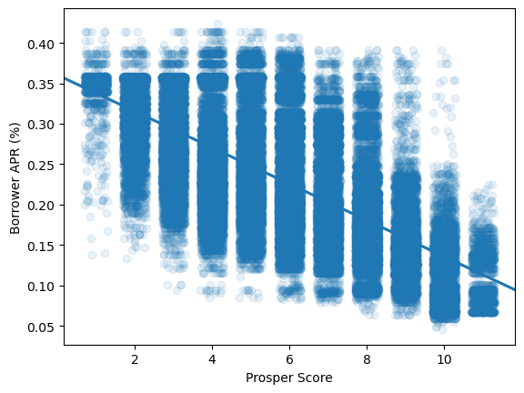

```python
# Visualize relationship between borrower APR and Prosper score using Seaborn's regplot() function.
sb.regplot(data = loan_data, x = 'ProsperScore', y = 'BorrowerAPR',
           truncate = False, scatter_kws = {'alpha' : 1/10}, x_jitter = 0.3)
plt.xlabel('Prosper Score')
plt.ylabel('Borrower APR (%)')
plt.show();
```

The plot shows a negative relationship between borrower APR and Prosper score. Higher scores correlate with lower annual percentage rates.

### 4.3. Relationship Between Borrower APR and Loan Term

We want to find whether there is a relationship between borrower APR and the loan term.

```python
# Function to create violin plot with Seaborn.
def violinplot(i, a):
    plt.figure(figsize = [7, 4])
    color = sb.color_palette()[0]
    sb.violinplot(data = loan_data, x = i, y = a, color = color);

# Function to create box plot with Seaborn.
def boxplot(i, a):
    plt.figure(figsize = [7, 4])
    color = sb.color_palette()[0]
    sb.boxplot(data = loan_data, x = i, y = a, color = color);
```

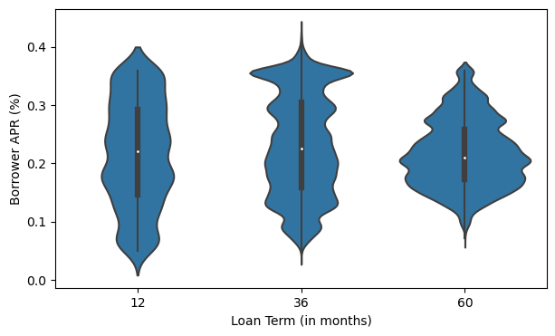

```python
# Visualize relationship between borrower APR and laon term using Seaborn's viollinplot() function.
ax1 = violinplot('Term', 'BorrowerAPR')
plt.xlabel('Loan Term (in months)')
plt.ylabel('Borrower APR (%)')
plt.show()
```

The violin plot above indiciates that there is no monotonic relationship between annual percentage rate and loan term.

### 4.4. Relationship Between Loan Amount and Home Ownership

Is there a relationship between original loan amount home ownership status of borrowers?

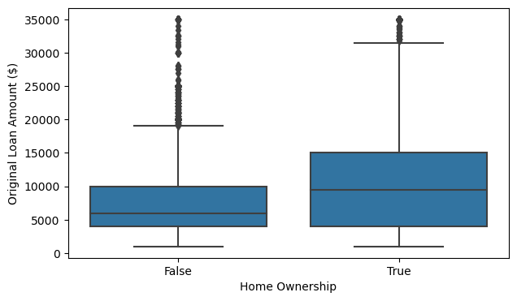

```python
# Visualize relationship between loan amount and home ownership using Seaborn's viollinplot() function.
boxplot('IsBorrowerHomeowner', 'LoanOriginalAmount')
plt.xlabel('Home Ownership')
plt.ylabel('Original Loan Amount ($)')
plt.show()
```

The box plot above indiciates that borrowers that own a home tend to take large loan amounts compared to those who don't own a home.

### 4.5. Relationship between Loan Amount and Income Range

Now, We will investigate whether there is a relationship between loan amount and borrower's income range.

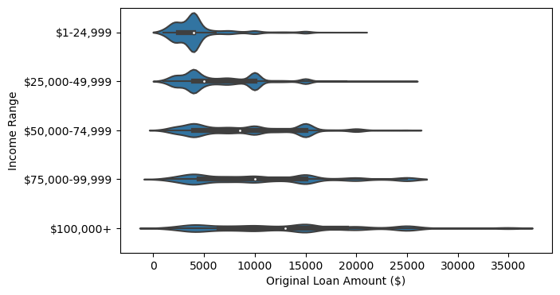

```python
# Visualize relationship between loan amount and home ownership using Seaborn's viollinplot() function.
violinplot('LoanOriginalAmount', 'IncomeRange')
plt.xlabel('Original Loan Amount ($)')
plt.ylabel('Income Range')
plt.show()
```

From the violin plot above, we can see the trend that the higher the income range of borrowers, the larger the amount of loan they take.

# 5. Multivariate Explorations

In this section, we will explore relationships between multiple variables.

### 5.1. Relationship Between Borrower APR , Prosper Score, and Loan Term

Are there differneces between lengths of loans in terms of borrower's Annual Percentage Rate and Prosper score?

```python
# Generate a random sample of 500 from the dataset.
sample = np.random.choice(loan_data.shape[0], 300, replace = False)
loan_data = loan_data.reindex(sample)
```

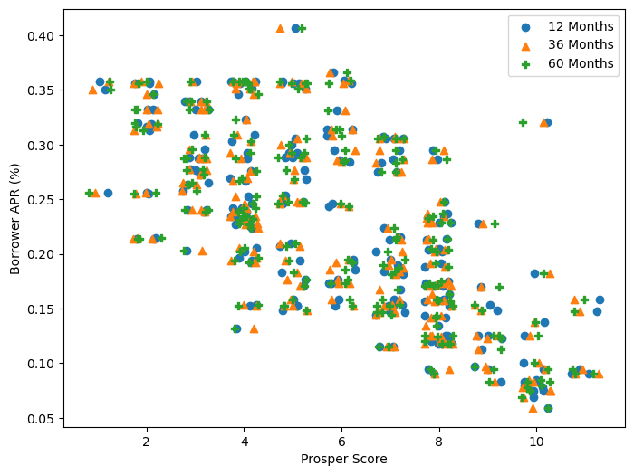

```python
# Visualize relationship between borrower APR, Prosper score, and term using Seaborn's regplot() function.

# Set plot figure size.
plt.figure(figsize = [8, 6])

# Set list of lists for the markers.
term_markers = [['12', 'o'], ['36', '^'], ['60', 'P']]

# Loop over the list elements.
for term, marker in term_markers:
    plot_data = loan_data[loan_data['Term'] == term]
    sb.regplot(data = loan_data, x = 'ProsperScore', y = 'BorrowerAPR',
           fit_reg = False, scatter_kws = {'alpha' : 1/1}, x_jitter = 0.3, marker = marker)

# Set labels and legend.
plt.xlabel('Prosper Score')
plt.ylabel('Borrower APR (%)')
plt.legend(['12 Months', '36 Months', '60 Months'])
plt.show();
```

### 5.2. Relationship between Loan Amount, Income Range, and Loan Term

Are there differneces between lengths of loans in terms of laon amount and income range?

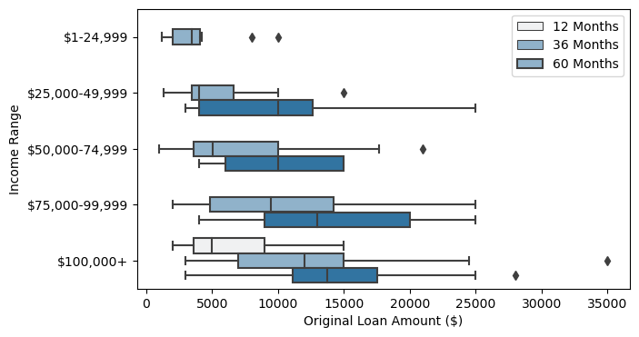

```python
# Visualize relationship between loan amount, income range, and term using Seaborn's pointplot() function.
plt.figure(figsize = [7, 4])
color = sb.color_palette()[0]

sb.boxplot(data = loan_data, x = 'LoanOriginalAmount', y = 'IncomeRange', hue = 'Term', color = color)

plt.xlabel('Original Loan Amount ($)')
plt.ylabel('Income Range')
plt.legend(['12 Months', '36 Months', '60 Months'])
plt.show();
```

The plot above indicates that borrowers that take loans of 60 months and with higher income ranges tend to take large loans.

### 5.3. Relationship between Loan Amount, Home Ownership, and Loan Term

Are there differneces between lengths of loans in terms of laon amount and home ownership?

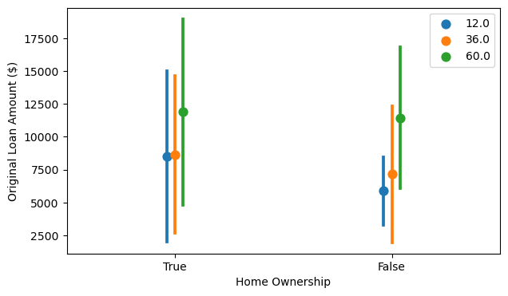

```python
# Visualize relationship between loan amount, home ownership, and term using Seaborn's pointplot() function.
plt.figure(figsize = [7, 4])

sb.pointplot(data = loan_data, x = 'IsBorrowerHomeowner', y = 'LoanOriginalAmount', hue = 'Term',
            ci = 'sd', linestyles = '', dodge = True)

plt.xlabel('Home Ownership')
plt.ylabel('Original Loan Amount ($)')
plt.legend()
plt.show()
```

# 6. Conclusion

# 7. Sources

1. https://pandas.pydata.org/pandas-docs/stable/reference/api/pandas.set_option.html
2. https://stackoverflow.com/questions/49188960/how-to-show-all-columns-names-on-a-large-pandas-dataframe
3. https://matplotlib.org/stable/api/markers_api.html
4. https://numpy.org/doc/stable/reference/random/generated/numpy.random.choice.html
5. https://towardsdatascience.com/8-commonly-used-pandas-display-options-you-should-know-a832365efa95
6. https://docs.python.org/3/library/warnings.html
7. https://pandas.pydata.org/pandas-docs/stable/reference/api/pandas.DataFrame.set_axis.html
8. https://pandas.pydata.org/pandas-docs/version/0.23/generated/pandas.api.types.CategoricalDtype.html
9. https://numpy.org/doc/stable/reference/generated/numpy.arange.html